# Redes Neuronales

## Ilustración Retropropagación

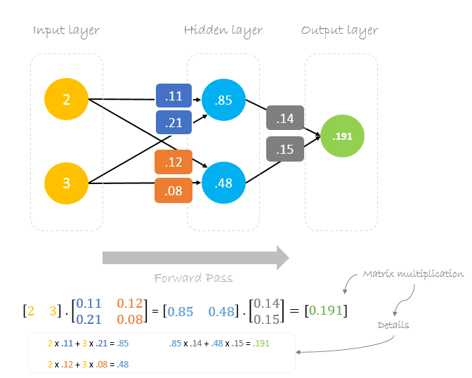

## Ilustración Retropropagación

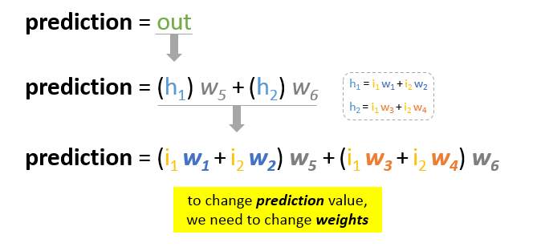

## Ilustración Retropropagación

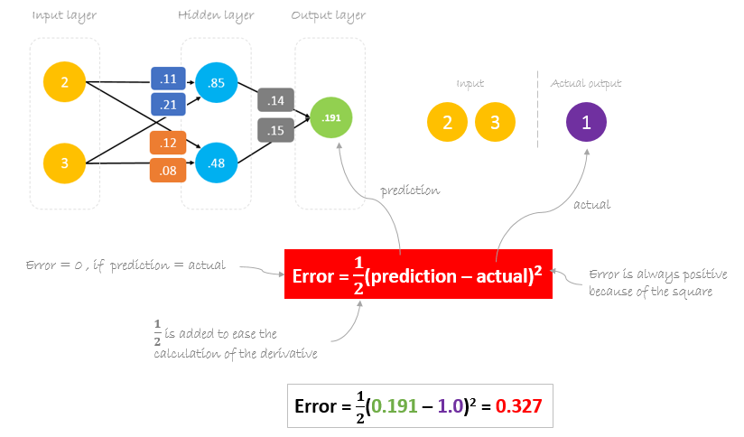

## Ilustración Retropropagación

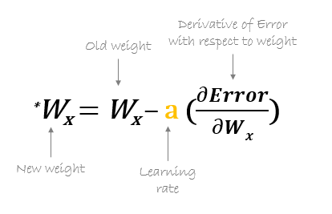

## Ilustración Retropropagación

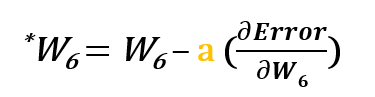

## Ilustración Retropropagación

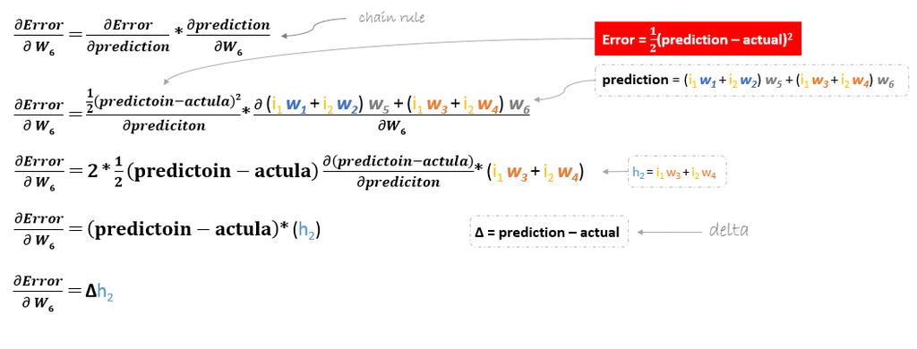

## Ilustración Retropropagación

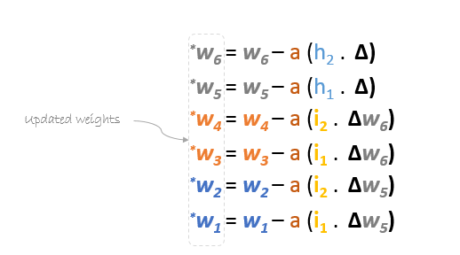

# Librerías

## Seleccionando Algoritmos

¿Cómo elijo el algoritmo más adecuado para mis datos?

## Comparación de Algoritmos

Comparación de distintos algoritmos a la fecha

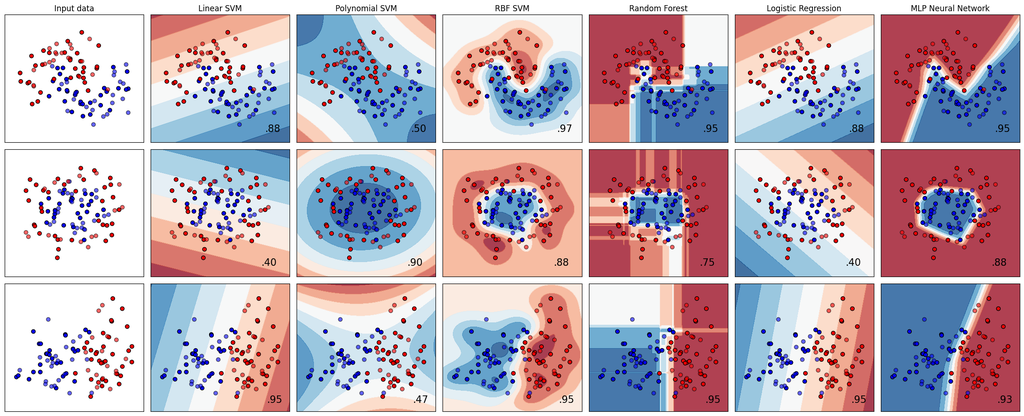

## Redes Neuronales en Python

- **Multilayer Perceptron (MLP) en Scikit-Learn:**
  - `sklearn.neural\_network.MLPClassifier`
  - `sklearn.neural\_network.MLPRegressor`
- **Redes Neuronales en Keras y TensorFlow:**
  - `tensorflow.keras.models.Sequential`
  - `tensorflow.keras.layers.Dense`

## Multilayer Perceptron (MLP): Hiperparámetros Clave

- `hidden\_layer\_sizes`: Tupla que define el número y tamaño de las capas ocultas (ej. `(100,)` para una capa de 100 neuronas).
- `activation`: Función de activación en las capas ocultas (`'relu'`, `'logistic'`, `'tanh'`).
- `solver`: Algoritmo de optimización (`'adam'`, `'sgd'`, `'lbfgs'`).
- `alpha`: Término de regularización L2 para evitar sobreajuste.
- `learning\_rate`: Controla la tasa de aprendizaje si se usa `sgd` como solver (`'constant'`, `'invscaling'`, `'adaptive'`).
- `max\_iter`: Número máximo de iteraciones para el entrenamiento.
- `random\_state`: Fija la semilla para reproducibilidad.

## Término de Regularización - Alpha

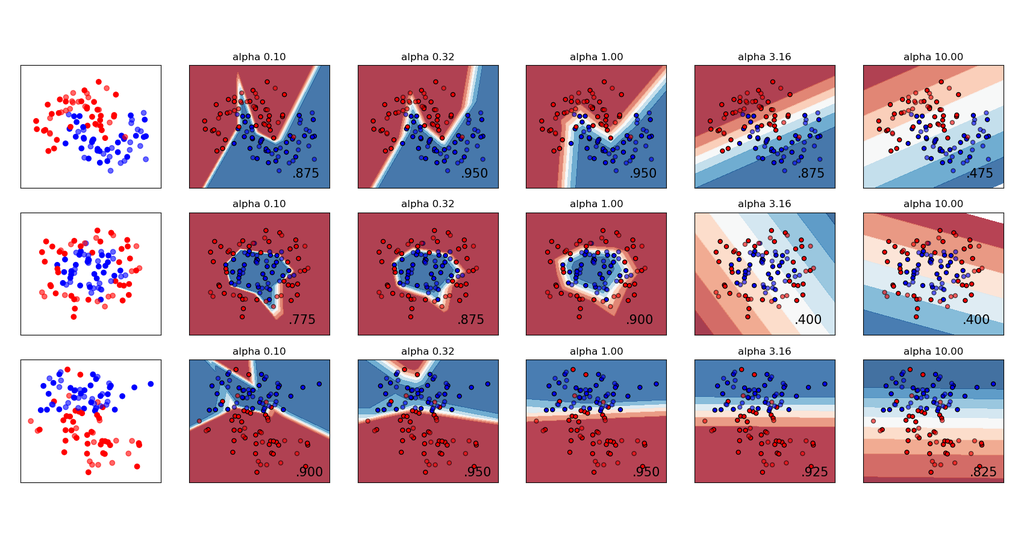

Término de Regularización y su impacto en las predicciones

## References

Rumelhart, David E, Geoffrey E Hinton, and Ronald J Williams. 1986. “Learning Representations by Back-Propagating Errors.” *Nature* 323 (6088): 533–36.